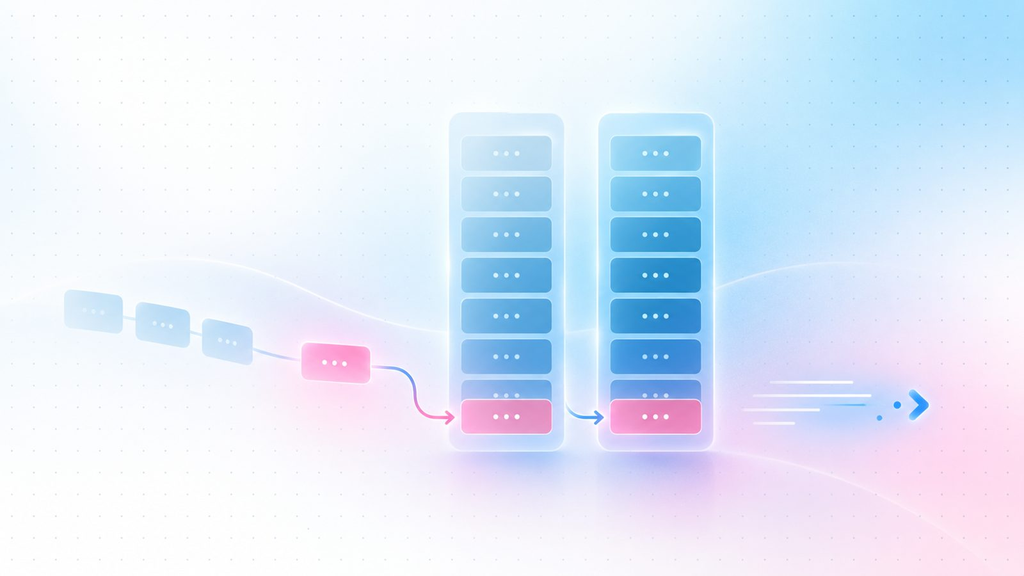

Transformers from scratch · Inference

# Inference 5× faster with KV caching dynamics

A GPT generates one token at a time. What if you could save all the previous tokens and only process the new one? Key and Value Caching is one such technique that helps you exactly the same.

KV cache Build notes Inference GPT-2 · 124M PyTorch

01

TL;DR

## The problem and the fix

A GPT generates one token at a time. What if you could save all the previous tokens and only process the new one?

This is the simple idea behind KV caching. Let's understand with an example.

Say the prompt is *"The cat sat"* and we want three more words. The model reads all of the text so far at every step:

Without a cache · the model re-reads everything*3 words in, 3 words out*

step 1Thecatsat→on

step 2Thecatsaton→the

step 3Thecatsatonthe→mat

"The", "cat" and "sat" are processed three times each, and the result is identical every time because in causal attention a word's computation depends only on the words before it. With a cache, the model keeps what it worked out about the old words and reads only the new one:

With a cache · only the new word is read*old words are remembered*

step 1Thecatsat→on

step 2Thecatsaton→the

step 3Thecatsatonthe→mat

K and V refer to the Key and Values in the attention mechanism. Saving Key and Value tensors (referred to as caching) allows the model to avoid recomputing attention for the words it has already seen. To know more about the attention mechanism, read this blog post.

[figure not shown]

Attention · Transformers · PyTorch

Attention in Transformers: From Equation to PyTorch, Checked by Hand

Queries, keys, values and the causal mask, built from scratch and verified in a spreadsheet — everything the cache below is made of.

02

Mechanism

## What the cache stores?

When the new token arrives, attention needs three things: the new token's **query**, and the **keys** and **values** of every token before it. The new token's query is compared against all keys to get attention weights, and those weights mix all the values. The earlier tokens' queries are never needed again — a query is only used to compute the output at its own position, and those outputs are already in the past.

So per attention layer we keep two tensors, one for keys and one for values, each of shape `(batch, heads, tokens_so_far, head_dim)`. Each step appends one row to both. GPT-2 has 12 layers, so there are 24 such tensors in total.

[figure not shown]

**Two phases.** Prefill runs the prompt in one pass and fills the cache; decode feeds a single token per step and appends to it. Every layer has its own K and V cache, so the picture repeats 12 times for GPT-2.

### Why nothing else needs caching

The MLP, the layer norms and the residual stream all act on one position at a time. For the new token they are computed fresh from that token's own path through the network. Earlier tokens influence the new one through exactly one door — the attention weights and the values they pull in — and the cache holds both sides of that door. Nothing else from the past is needed.

03

Arithmetic

## How much it saves, and what it costs

The saving is in compute per step; the cost is memory that grows with the sequence.

Without the cache, step *t* pushes *t* tokens through every linear layer and computes a *t*×*t* attention matrix. With it, step *t* pushes one token through the linear layers and computes a 1×*t* attention row. Summed over a generation of *n* tokens, the linear-layer work drops from quadratic in *n* to linear, and the attention work drops from cubic to quadratic.

The memory bill is easy to write down. Per sequence, the cache holds two tensors per layer, each `tokens × n_embd` numbers:

cache bytes = 2 × layers × tokens × n_embd × bytes per number  
GPT-2 at its full 1,024-token context in fp32: 2 × 12 × 1,024 × 768 × 4 ≈ 75 MB

5,850

token positions processed by the plain loop for 100 new tokens

108

token positions processed with the cache — a 54× cut in work

24

cache tensors for GPT-2 (K and V for each of 12 layers)

75 MB

cache per sequence at 1,024 tokens, fp32 — the weights are 498 MB

For a 124M model generating a hundred tokens, 75 MB is nothing. For a 70B model serving many users with long contexts, the cache — not the weights — is what fills the GPU. That is the problem grouped-query attention and KV-cache quantization exist to solve, and it is the reason the cache is worth understanding at small scale first.

04

Change 1 of 4

## The config switch

Starting point: Andrej Karpathy's GPT-2 from *build-nanogpt*, with the cache design from Sebastian Raschka's *Coding the KV Cache in LLMs from Scratch*. Everything below is the diff between the two.

GPTconfig

```
@dataclass
class GPTconfig:
    vocab_size: int = 50304
    block_size: int = 1024
    n_embd:     int = 768
    n_layers:   int = 12
    n_head:     int = 12
    use_cache:  bool = False   # the switch
```

- **One boolean, one place.** `use_cache` lives on the config dataclass next to the model dimensions.
- **Every layer already holds the config.** In nanoGPT, `GPT`, each `Block` and each `CausalSelfAttention` store `self.config = config` — the same object, not copies. So `model.config.use_cache = True` reaches all 12 attention layers at once.
- **No forward signatures change.** Raschka threads a `use_cache` argument through `GPT.forward → Block.forward → Attention.forward`. With the flag on the config, the training loop calls `model(x, y)` exactly as before and the flag defaults to off.
- **The trade-off.** The flag is shared mutable state. Whoever turns it on must turn it off; our `generate` does both.

**Pitfall · leaving the switch on**

If `use_cache` is still `True` when training resumes, every forward pass appends its batch to the cache and advances the position counter — first a shape mismatch, or quietly, positions indexed past `block_size`. Reset the flag and the cache at the end of generation, every time.

05

Change 2 of 4

## Attention: store, append, mask correctly

Two buffers, a few lines that append to them, a reset method, and one changed argument to `scaled_dot_product_attention`.

CausalSelfAttention · additions highlighted

```
class CausalSelfAttention(nn.Module):
    def __init__(self, config):
        super().__init__()
        self.config = config
        self.c_attn = nn.Linear(config.n_embd, 3 * config.n_embd)
        self.c_proj = nn.Linear(config.n_embd, config.n_embd)
        self.n_head, self.n_embd = config.n_head, config.n_embd
        self.register_buffer("k_cache", None, persistent=False)
        self.register_buffer("v_cache", None, persistent=False)

    def forward(self, x):
        B, T, C = x.size()
        q, k, v = self.c_attn(x).split(self.n_embd, dim=2)
        k = k.view(B, T, self.n_head, C // self.n_head).transpose(1, 2)  # (B, nh, T, hs)
        q = q.view(B, T, self.n_head, C // self.n_head).transpose(1, 2)
        v = v.view(B, T, self.n_head, C // self.n_head).transpose(1, 2)

        if self.config.use_cache:
            if self.k_cache is None:                      # prefill: start the cache
                self.k_cache, self.v_cache = k, v
            else:                                        # decode: append one row
                self.k_cache = torch.cat([self.k_cache, k], dim=2)
                self.v_cache = torch.cat([self.v_cache, v], dim=2)
            k, v = self.k_cache, self.v_cache               # attend over everything

        y = F.scaled_dot_product_attention(q, k, v, is_causal=(k.size(2) == T))

        y = y.transpose(1, 2).contiguous().view(B, T, C)
        return self.c_proj(y)

    def reset_cache(self):
        self.k_cache, self.v_cache = None, None
```

- **Buffers, not attributes.** `register_buffer` makes the cache part of the module, so `model.to(device)` moves it with the weights. Assigning `self.k_cache = ...` to a registered name replaces the buffer in place.
- **`persistent=False`** keeps the cache out of `state_dict`, so a checkpoint never drags stale cache along with it.
- **First call fills, later calls append.** An empty cache means prefill: store K and V for the whole prompt. A non-empty cache means decode: concatenate the new row and attend over everything.
- **The mask is conditional.** `is_causal=True` is only correct when the number of queries equals the number of keys — the no-cache path and the prefill pass. During decode, one query faces *T*+1 keys and must see all of them, so no mask is applied.

**Pitfall · `is_causal=True` with a cache**

PyTorch anchors the causal mask to the **top-left** corner: query *i* sees keys 0 … *i*. With a single decode query that means query 0 sees key 0 — the first word of the prompt — and nothing else. Shapes are valid, nothing errors, and the output is garbage. Mask only when `q` and `k` have the same length.

**Pitfall · `torch.cat` every step**

Concatenation copies the whole cache on each step. It is fine at GPT-2's 1,024-token context and keeps the code short; production code pre-allocates the full `(B, nh, block_size, hs)` buffer once and writes into a slice.

06

Change 3 of 4

## Positions: the token has to know where it is

GPT-2 uses learned absolute position embeddings. A token fed on its own would be told it is at position 0 unless we say otherwise.

GPT.forward · position offset

```
def forward(self, idx, targets=None):
    B, T = idx.size()
    if self.config.use_cache:
        pos = torch.arange(self.current_pos, self.current_pos + T, device=idx.device)
        self.current_pos += T
    else:
        pos = torch.arange(0, T, device=idx.device)
    x = self.transformer.wte(idx) + self.transformer.wpe(pos)
    ...

def reset_kv_cache(self):
    for blk in self.transformer.h:
        blk.attn.reset_cache()
    self.current_pos = 0
```

- **A counter on the model.** `current_pos` starts at 0. The prefill pass embeds the prompt at positions 0 … *T*−1 and moves the counter to *T*.
- **Each decode step uses the next slot.** One token in, embedded at `current_pos`, counter advanced by one.
- **One reset for everything.** `reset_kv_cache` clears every layer's cache and zeroes the counter in a single call.

**Pitfall · forgetting the offset**

This is the failure that does not crash. Every decode step uses `pos = 0`, the model believes each new token is the first word of a document, and the text degrades after a few tokens. The check against the no-cache output is what catches it.

07

Change 4 of 4

## The generation loop

Prefill with the whole prompt, then feed back only the newest token. Reset on the way in and on the way out.

generate

```
@torch.no_grad()
def generate(model, idx, max_new_tokens, use_cache=True):
    model.eval()
    ctx_len = model.config.block_size
    if use_cache:
        assert idx.size(1) + max_new_tokens <= ctx_len, "prompt + new tokens exceed block_size"
    model.config.use_cache = use_cache
    model.reset_kv_cache()

    inp = idx[:, -ctx_len:]                        # prefill with the full prompt
    for _ in range(max_new_tokens):
        logits, _ = model(inp)
        next_token = torch.argmax(logits[:, -1, :], dim=-1, keepdim=True)
        idx = torch.cat([idx, next_token], dim=1)
        inp = next_token if use_cache else idx[:, -ctx_len:]   # cache: only the new token

    model.config.use_cache = False
    model.reset_kv_cache()
    return idx
```

- **Switch on, reset, prefill.** The first forward pass sees the full prompt and fills every layer's cache.
- **Then one token at a time.** With the cache, `inp` is just the newest token; without it, `inp` is the whole sequence so far. That line is the only difference between the two paths.
- **Switch off, reset, return.** The model is left exactly as it was found.
- **Greedy decoding makes it testable.** `argmax` is deterministic, so a correct cache must reproduce the uncached tokens exactly — checked with `torch.equal`.

**Pitfall · the context window becomes a hard ceiling**

The no-cache path can keep going past `block_size` by sliding (`idx[:, -ctx_len:]` drops the oldest tokens). The cached path cannot — old keys are still in the cache and the position counter climbs past the embedding table. Hence the assert.

**Pitfall · a stale cache from the previous call**

Without the reset at the top, a second call to `generate` would attend over the previous prompt's keys as well as its own. Reset before prefill, not just after decode.

08

Measuring

## Measuring it fairly

A speed-up claim needs a fair baseline, a warm-up, and a correctness check.

benchmark

```
def benchmark(model, idx, max_new_tokens, use_cache, n_runs=2):
    generate(model, idx, 5, use_cache=use_cache)        # warm-up
    t0 = time.perf_counter()
    for _ in range(n_runs):
        out = generate(model, idx, max_new_tokens, use_cache=use_cache)
    dt = (time.perf_counter() - t0) / n_runs
    return out, idx.size(0) * max_new_tokens / dt      # tokens per second
```

- **Same function, same model, same prompt.** Only the `use_cache` flag differs between the two runs.
- **Warm up first.** The first call pays for CUDA setup and allocator growth; it is never timed.
- **Outputs must match.** `torch.equal(out_cache, out_no_cache)` was `True` for every model on both devices.
- **`torch.compile` stays off.** It specialises on shapes, and the cache changes shape every step, so each step would recompile.
- **GPU timing caveat.** CUDA is asynchronous; a `torch.cuda.synchronize()` before stopping the clock would make the GPU numbers exact. The decode loop is mostly forced into step with the device anyway, and the CPU numbers have no such caveat.

09

Results

## 3× on GPU, 5× on CPU — same text out

Greedy decoding, randomly initialised models (speed does not depend on the weights), `torch.compile` off.

2.97×

GPT-2 124M on GPU · 5 sequences × 100 tokens · 1.22 s → 0.41 s

5.33×

GPT-2 124M on CPU · 5 sequences × 100 tokens · 8.0 s → 1.5 s

0

tokens that differed between cached and uncached output, across all runs

### Across model sizes

One sequence, 200 new tokens, four models from 16M to 774M parameters.

[figure not shown]

**Tokens per second, higher is better.** Light bars are without the cache, dark bars with it; the number at the end of each pair is the speed-up.

| Model | Layers | Dim | Heads | Params | GPU no cache | GPU cache | Speed-up | CPU no cache | CPU cache | Speed-up |
| --- | --- | --- | --- | --- | --- | --- | --- | --- | --- | --- |
| tiny | 4 | 256 | 4 | 16M | 648.3 | 849.3 | 1.31× | 186.1 | 612.0 | 3.29× |
| gpt2 | 12 | 768 | 12 | 124M | 116.6 | 342.5 | 2.94× | 26.1 | 100.3 | 3.84× |
| gpt2-medium | 24 | 1024 | 16 | 355M | 60.7 | 152.1 | 2.51× | 7.8 | 31.5 | 4.06× |
| gpt2-large | 36 | 1280 | 20 | 774M | 26.8 | 80.9 | 3.02× | 4.0 | 17.6 | 4.37× |

Dim is the embedding width (`n_embd`); throughput in tokens per second. Outputs matched between the cached and uncached runs in all eight comparisons.

### Reading the numbers

- **Why not 54×?** The cache removes the redundant transformer compute, not the fixed cost of each step — the Python loop, 12 layers of kernel launches, the `argmax`, and the output projection over a 50,304-word vocabulary. Those now dominate.
- **Why the CPU gains more.** A CPU is compute-bound, so every deleted operation is time saved; the speed-up climbs steadily with model size, 3.3× → 4.4×.
- **Why the GPU gains less.** At batch size 1 a GPU is bound by launch overhead and weight loading, not arithmetic — much of the wasted compute was running in otherwise idle lanes.
- **Why the 16M model barely moves on GPU.** Each step is microseconds of math inside a fixed overhead; the cache can only shave the math. `torch.compile` and CUDA graphs are the tools for that regime.
- **Why longer generations gain more.** Uncached cost grows quadratically with tokens generated, cached cost roughly linearly. At 100–200 tokens these ratios are a lower bound; a chat-length reply would show a far larger gap.

The cache removed the redundant arithmetic.  
What is left is overhead — and that is the next thing to attack.

10

Recap

## The pitfalls, collected

Every one of these produces valid tensor shapes and a running program. Only the last two raise an error.

1. The causal mask anchored to the wrong cornerA single decode query with `is_causal=True` sees only the first key. Apply the mask only when query and key lengths match.
2. Position 0 for every new tokenLearned absolute embeddings need the offset. Keep a counter, advance it by the number of tokens fed, reset it with the cache.
3. A stale cache from the last callReset before prefill as well as after decode.
4. Trusting a faster numberCompare the generated tokens with the uncached path under greedy decoding. A mismatch means the cache is wrong, however fast it is.
5. Timing the warm-up or the queueRun once before the clock starts; synchronise the GPU before it stops.
6. Leaving the switch onShared config state is convenient to flip and easy to forget. `generate` owns both the on and the off.
7. Generating past the context windowThe cached path cannot slide. Assert `prompt + new tokens ≤ block_size`, or implement eviction.

### Where to go from here

- **Pre-allocate the cache** at `block_size` and write into slices — removes the per-step copy and makes `torch.compile` usable again.
- **Grouped-query attention** shares one K/V head across several query heads and shrinks the cache by that factor.
- **Sliding-window eviction** drops the oldest rows so generation can run past the context window.
- **Batched serving** with padding and per-sequence position counters, where PagedAttention-style block allocation comes in.

Contents

- 1 · TL;DR
- 2 · What the cache stores
- 3 · How much it saves
- 4 · The config switch
- 5 · Attention changes
- 6 · Position offset
- 7 · The generation loop
- 8 · Measuring fairly
- 9 · Results
- 10 · Pitfalls, collected